# (A)symmetry

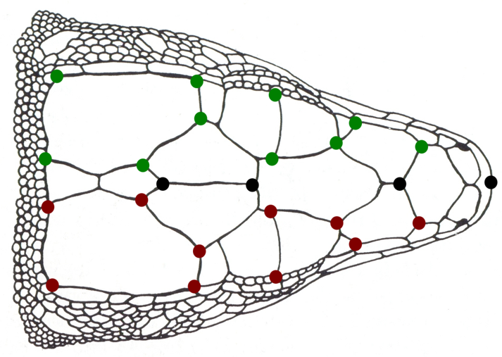

Antigoni Kaliontzopoulou, Universitat de Barcelona

02 June, 2026

# Symmetry and Asymmetry

- Many objects are built symmetrically
- Paired structures and serially homologous body parts are organized in a symmetric way
- Bilateral symmetry: structures arranged in either side of the body mid-line (axis of symmetry)
- Symmetry poses some challenges for morphometric data analysis

# Types of Bilateral Symmetry

- Two main types of bilateral symmetry:
- **Matching symmetry**: pairs of structures are found across the mid-line of the object (e.g. insect wings, tetrapod limbs etc)
- **Object symmetry**: single structure with internal structural symmetry (e.g. structures in vertebrate skull)

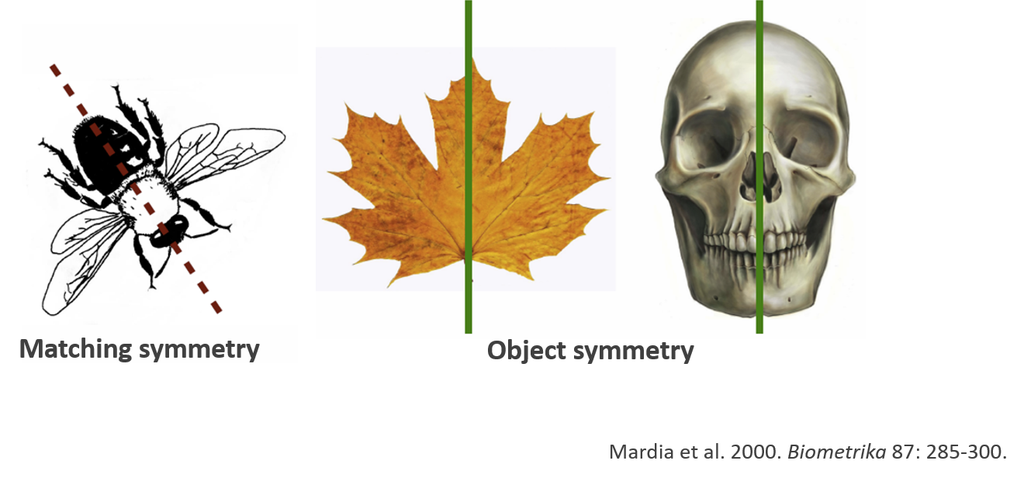

# The Problem with Symmetrical Objects

- Landmark positions are not independent in symmetric objects
- Lack of statistical independence for paired landmarks
- Some dimensions of shape space have little variance
- SSCP matrices become singular (or nearly so)
  - This causes issues with parametric statistical hypothesis-testing methods (‘divide’ by zero)

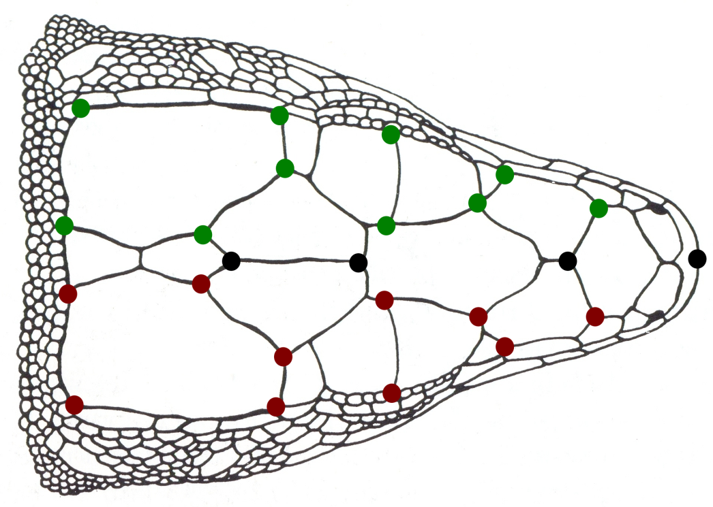

- The problem becomes worse as objects become more symmetric!
- Solution: use **entire structure** and **RRPP** for statistical evaluation!

###### As we have seen, RRPP, combined with robust summary test statistics, does not require inverting (nearly) singular covariance matrices, so model evaluation is not compromised by this issue.

# Symmetric Objects: Example

- Note the large number of shape dimensions with no variation. Much of this is due to bilateral symmetry!

```
##
## No curves detected; all points appear to be fixed landmarks.
```

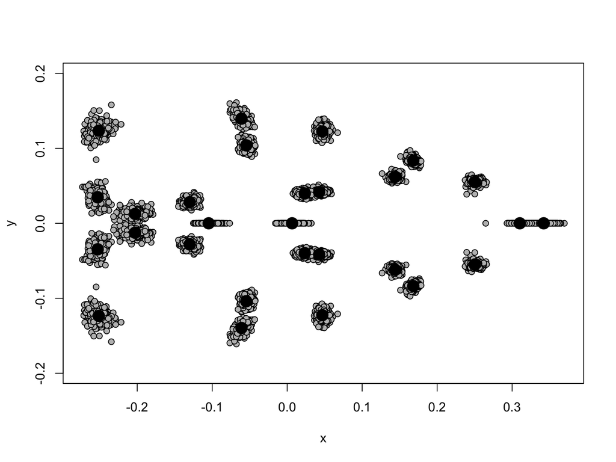

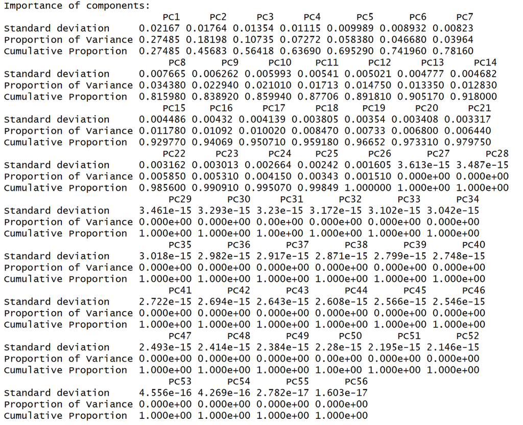

# The Biology of Asymmetry

- Different types of asymmetry are thought to have a biological meaning
- **Directional asymmetry**: consistent difference skewed towards one of the sides (at the population level); thought to reflect difference in use, e.g. fiddler crabs feeding vs. fighting displays

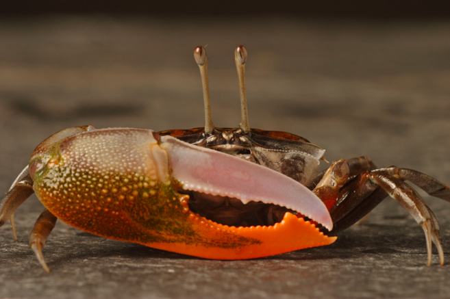

- **Fluctuating asymmetry**: thought to reflect instability during development (genetic, environmental etc)
- Long debate about the meaning of FA

# Types of Symmetry

- Perfect symmetry is rare in biology; objects nearly always have some degree of asymmetry
- Three main types of asymmetry have been described, based on the statistical distribution of asymmetry in the population
- **1: Directional**: consistent $\small{(R-L)}$ differences with one side always larger than the other: $\small{\overline{(R-L)}\neq0}$
- **2: Fluctuating**: small random $\small{(R-L)}$ deviations with $\small{\overline{(R-L)}=0}$
- **3: Antisymmetry**: consistent $\small{(R-L)}$ differences, but larger side random

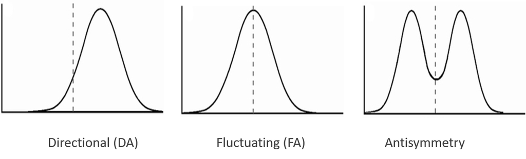

# Analysis of Symmetry: General Procedure

- The presence of various types of asymmetry may be evaluated using one of several factorial ANOVA designs
- Traits need to be quantified multiple times, so that measurement error may be quantified
- This allows one to evaluate if the (normally small) differences between sides are actually “real” or due to measurement error (ME)
- ANOVA then often set up as:

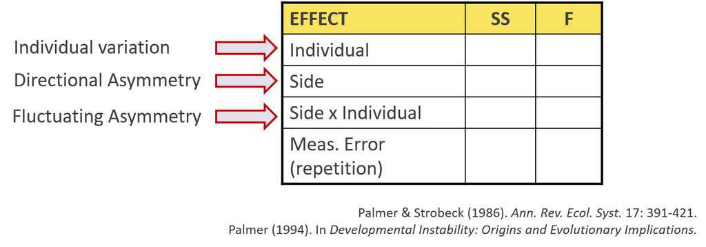

# Extensions to GM Shape Data

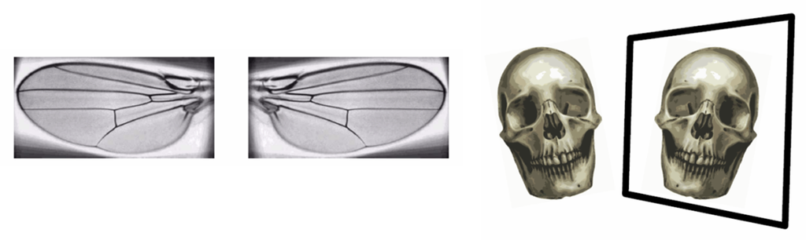

- **Procedure**
  - 1: Digitize right and left structures (or R and L sides), possibly multiple times for ME
  - 2: Reflect one side to match the other (and relabel landmarks for object symmetry)
  - 3: GPA + projection to tangent space
  - 4: Factorial ANOVA – SS for Individual, SS Side (DA), SS Side x Individual (FA)
  - 5: Assess model factors via permutation approaches

###### Klingenberg & McIntyre (1998). *Evolution.*; Klingenberg et al. (2002). *Evolution.*

# Decomposition of Asymmetry Component

- One can approach the problem more theoretically (rather than ‘procedurally’)
  - ANOVA effects respresent Sums of Squares, which correspond to various asymmetry components
  - Therefore, decomposing SST (total shape variation) obtained via $\small{D}_Proc$ provides variance components for both DA and FA

$$\small{SST}=\sum^n_1{D}^2_{(X_i,Y_i)}=nD^2_{(\overline{X},\overline{Y})}+\sum^n_1{D}^2_{(X_i-\overline{X},Y_i-\overline{Y})}$$

- where: $\small{nD}^2_{(\overline{X},\overline{Y})}$ represents the **Directional Asymmetry** component
- and: $\small\sum^n_1{D}^2_{(X_i-\overline{X},Y_i-\overline{Y})}$ represents the **Fluctuating Asymmetry** component

###### Mardia et al. (2000). *Biometrika*.

# Matching Symmetry: Example

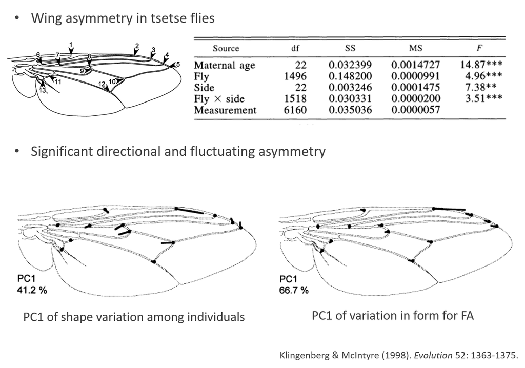

# Object Symmetry: Example

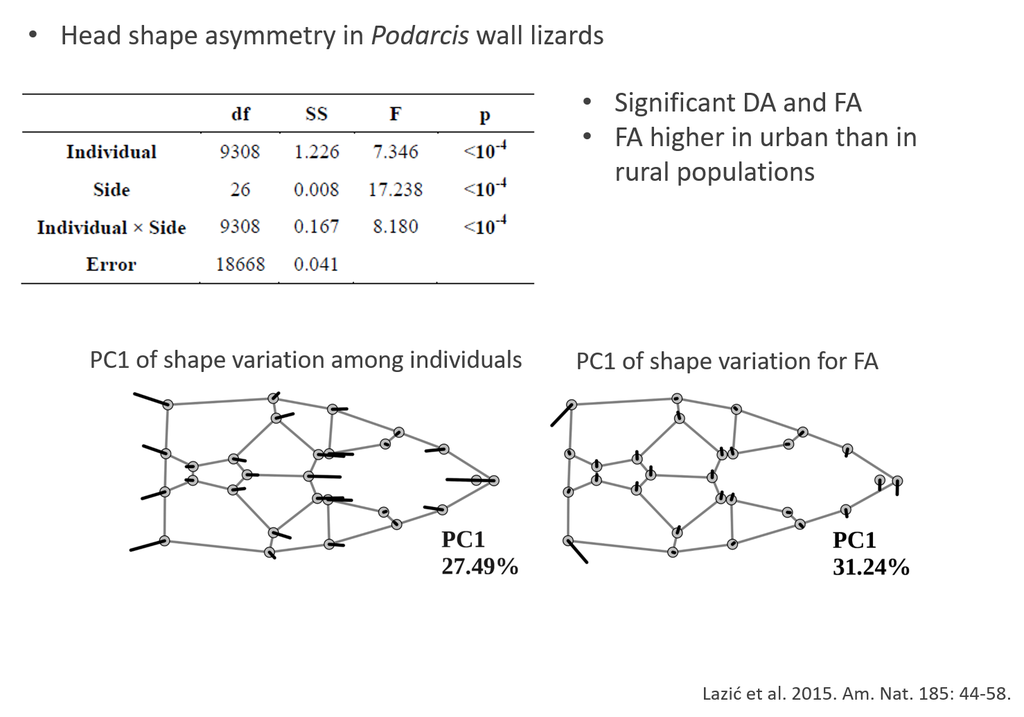

# Other Types of Asymmetry

- Many other types of (a)symmetry are present in biological data
- How can we quantify asymmetry for these structures?

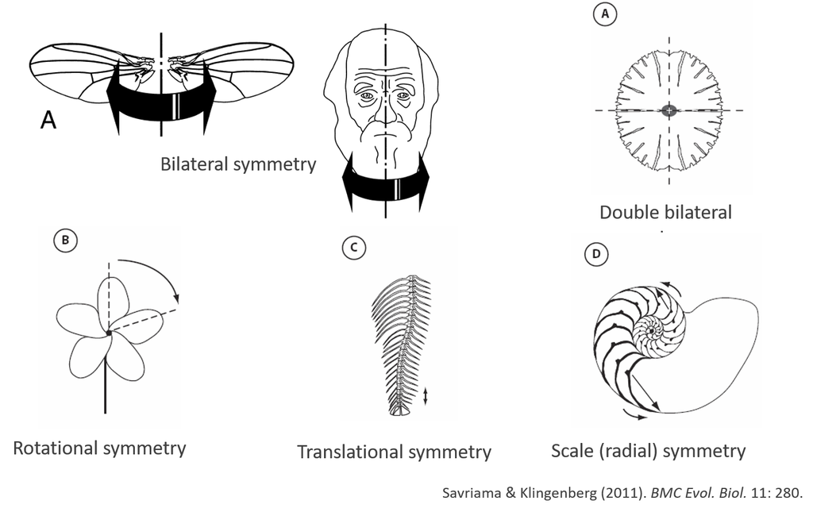

# Symmetry Groups

- One can approach the problem by defining **Symmetry Groups**
- Symmetry groups: transformations that leave the data invariant
- e.g.: bilateral symmetry = reflection across the midline

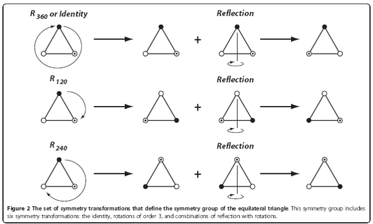

- Symmetry groups define transformations such that there are invariances in those symmetric ‘dimensions’
- These groups describe the ways in which symmetry can be defined, and thus quantified for more complex structures (e.g., radial symmetry)

###### Savriama and Klingenberg. (2011). *BMC Evol. Biol.*

# Symmetry: Extended Protocol

- For bilateral asymmetry: transformation = reflection
- For other types, decompose asymmetry to the components defining the symmetry type based on the appropriate symmetry groups

# Symmetry: Extended Protocol

- Example: Radial Symmetry

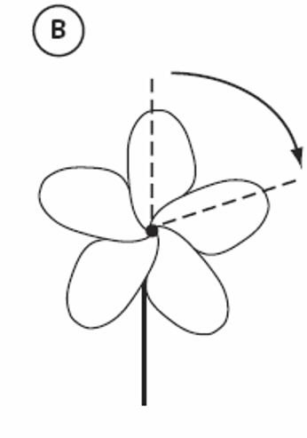

  - Digitize all p components
  - GPA + projection
  - Decompose shape variation into symmetry components, quantify and evaluate

###### Savriama and Klingenberg. (2011). *BMC Evol. Biol.*

# Complex Symmetry: Example

- Symmetry Analysis in corals

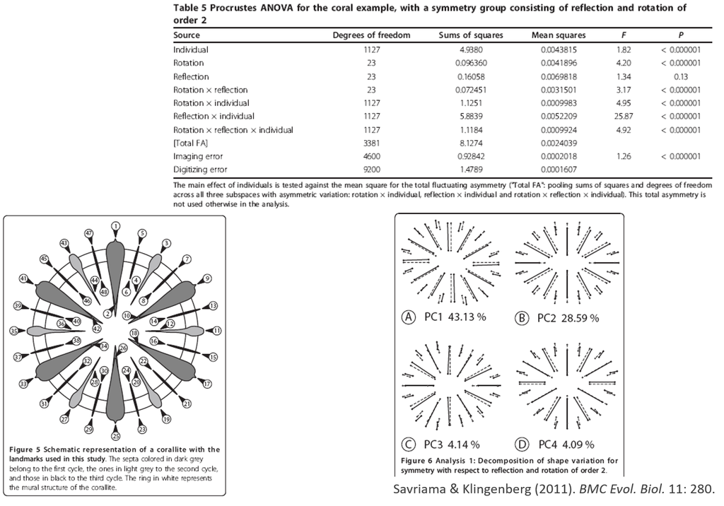

# A Note on Geometric Transformations

- Any captured shape difference that follows a geometric rule can be modelled using the Procrustes paradigm
- We can account for undesired effects
- We can model shapes and other effects separately
- Articulations frequently cause this kind of effects
- Shape effects + positional effects

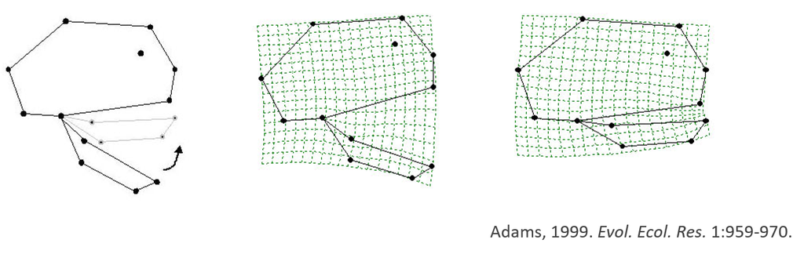

# Geometric Transformations: Articulations

For articulated structures, several solutions exist - Fixing the angle in all specimens through a mathematical transformation - Separating the subsets to analyse separately, etc.

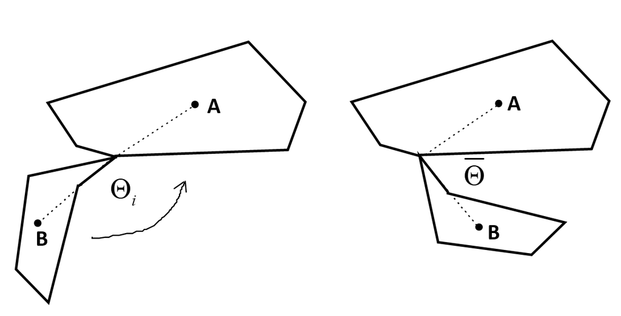

###### Adams. (1999). *Evol. Ecol. Res.*

# Articulation Standardization: Example

- Standardize some data for relative jaw position

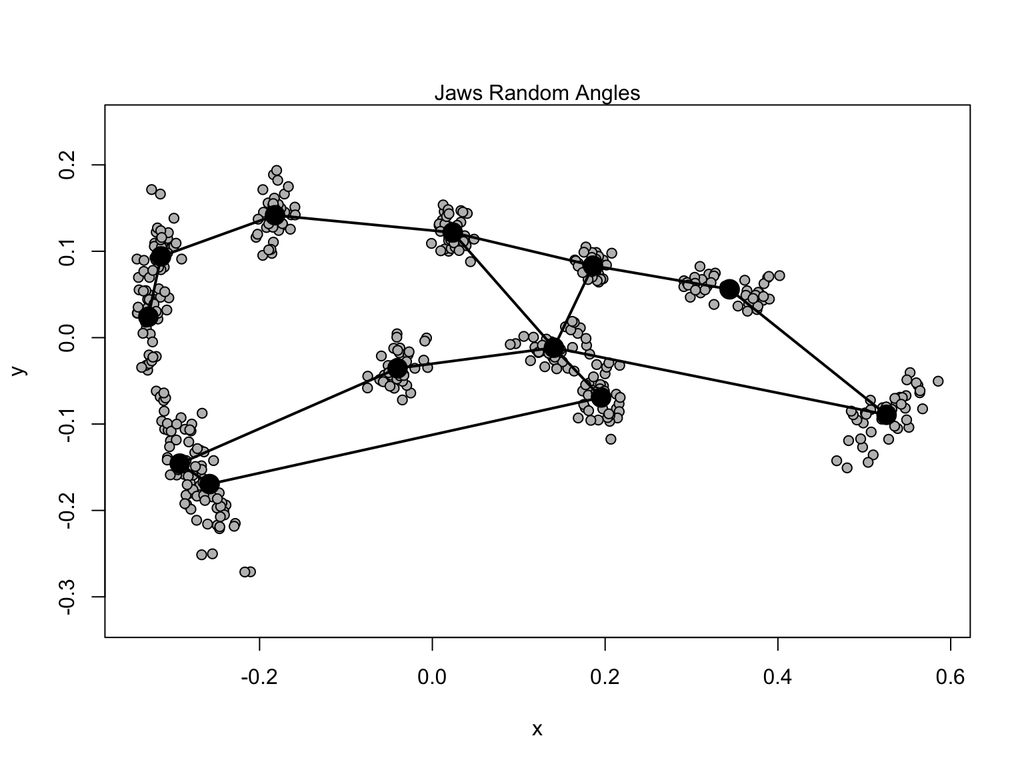

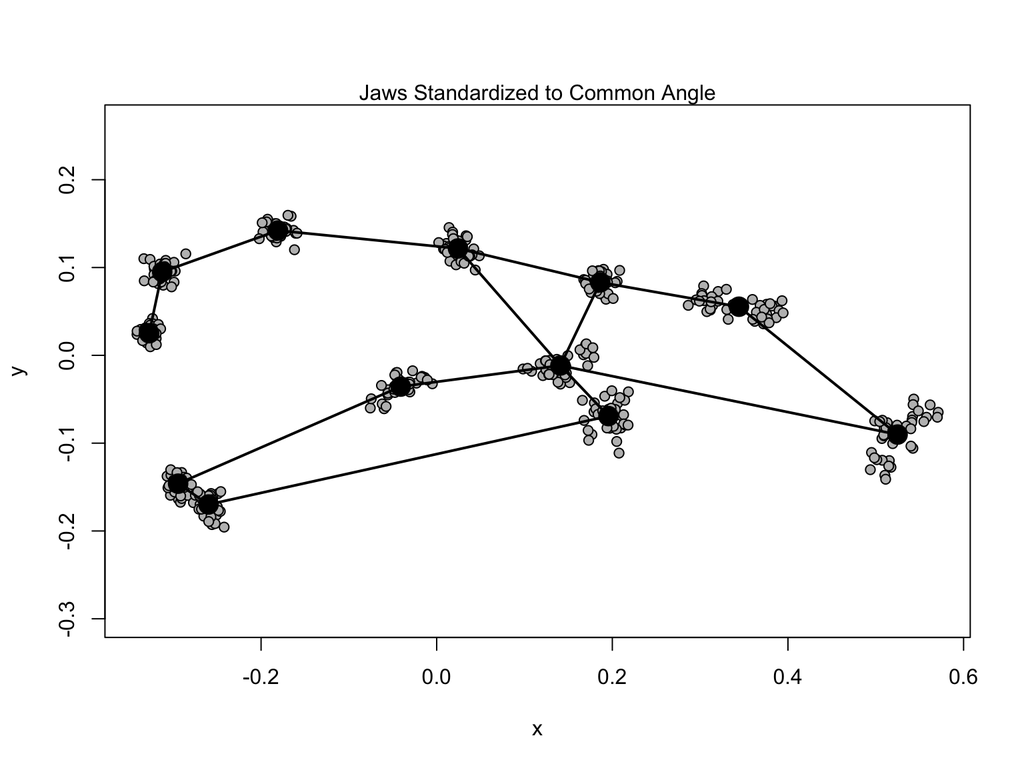

# Another Note on Geometric Transformations

- Considering ‘fixing’ articulation angles in reverse results in a different pattern **motion analysis**
  - For shape devoid of movement, one fixes the angle.
  - For quantifying movement, one compares shapes across the motion path interested
- The latter forms a *trajectory* that describes the motion path
- It is represented by a sequence of shapes (a trajectory) in shape space

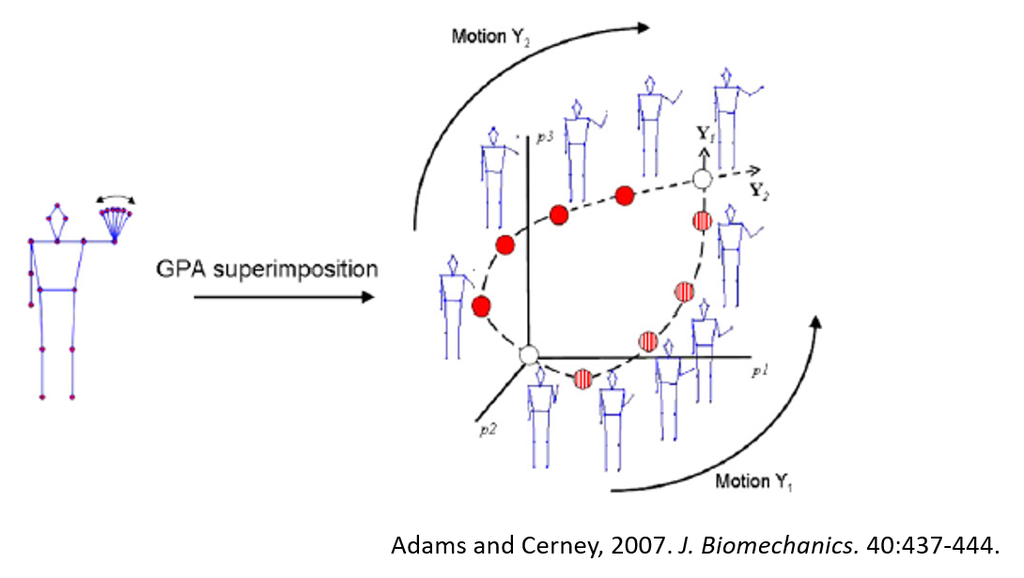

# Symmetry: Summary

- Symmetry causes redundancy in shape data
- Can account for symmetry effects analytically
- Asymmetry: biological significance
- FA: developmental instability
- DA: adaptation?
- Use ANOVA procedures to separate variation within (asymmetry) and among individuals
- Extensions to different types of symmetry
- Geometric transformations in general: any effect that follows a geometric rule can be taken into account, partialed out, or targeted in the Procrustes framework